# Matplotlib

Matplotlib is a Python 2D plotting library which produces publication quality figures in a variety of hardcopy formats and interactive environments across platforms.

## Installation

```
pip install matplotlib
```

## Pyplot

Pyplot is a Matplotlib module which provides a MATLAB-like interface. Matplotlib is designed to be as usable as MATLAB, with the ability to use Python, and the advantage of being free and open-source.

```python
#The inlining is only needed for ipython or Jupyter notebooks
%matplotlib inline

import matplotlib.pyplot as plt
```

## Parts of a Graph:

### Figure:

The working space in matplotlib is a Figure

### Axes:

This is what you think of as 'a plot', it is the region of the image with the data space. A given figure can contain many Axes, but a given Axes object can only be in one Figure.

### Axis:

These are the number-line-like objects.The Axes contains two (or three in the case of 3D) Axis objects (be aware of the difference between Axes and Axis) which take care of the data limits (the data limits can also be controlled via set via the set_xlim() and set_ylim() Axes methods).

### Subplot:

In the current figure, create and return an Axes, at position index of a (virtual) grid of nrows by ncols axes. Indexes go from 1 to nrows * ncols, incrementing in row-major order. Example: plt.subplot(221)

[figure not shown]

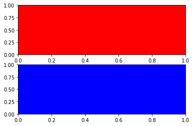

```python
#Here, we plot 211 & 212, where 2 <- rows; 1 <- columns; 1(or)2 <- index
plt.subplot(211,facecolor='r')
plt.subplot(212,facecolor='b')
plt.show()
```

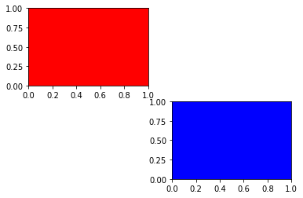

```python
plt.subplot(221,facecolor='r')
plt.subplot(224,facecolor='b')
plt.show()
```

## Line Graph:

Syntax: plt.plot(x,y,label='',linewidth=)

Lets, plot a normal line graph:

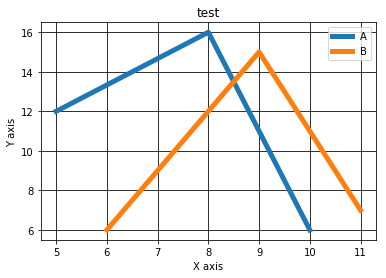

```python
x = [5,8,10]
y = [12,16,6]
x2 = [6,9,11]
y2 = [6,15,7]

plt.plot(x,y,label = 'A',linewidth = 5)
plt.plot(x2,y2,label = 'B',linewidth = 5)

plt.title('test')
plt.ylabel('Y axis')
plt.xlabel('X axis')
plt.legend()
plt.grid(color = 'k') #k=black

plt.show()
```

## Bar Graphs:

Instead of plot here we use bar

```
plt.bar([position_on_horizontal],[height_on_vertical],
label="label_name",width= width_value)
```

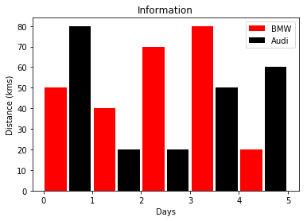

```python
plt.bar([0.25,1.25,2.25,3.25,4.25],[50,40,70,80,20],
label="BMW",width=.45,color='r')
plt.bar([.75,1.75,2.75,3.75,4.75],[80,20,20,50,60],
label="Audi", color='k',width=.45)

plt.legend()
plt.xlabel('Days')
plt.ylabel('Distance (kms)')
plt.title('Information')

plt.show()
```

## Histograms:

A histogram is an accurate representation of the distribution of numerical data. It differs from a bar graph, in the sense that a bar graph relates two variables, but a histogram relates only one.

pyplot command is : `matplotlib.pyplot.hist(x, bins=None, range=None, density=None, weights=None, cumulative=False, bottom=None, histtype='bar', align='mid', orientation='vertical', rwidth=None, log=False, color=None, label=None, stacked=False, normed=None, hold=None, data=None, **kwargs)`

x : (n,) array or sequence of (n,) arrays Input values, this takes either a single array or a sequence of arrays which are not required to be of the same length bins : integer or sequence or 'auto', optional If an integer is given, bins + 1 bin edges are calculated and returned, consistent with numpy.histogram().

If bins is a sequence, gives bin edges, including left edge of first bin and right edge of last bin. In this case, bins is returned unmodified.

All but the last (righthand-most) bin is half-open. In other words, if bins is:

[1, 2, 3, 4] then the first bin is [1, 2) (including 1, but excluding 2) and the second [2, 3). The last bin, however, is [3, 4], which includes 4.

Unequally spaced bins are supported if bins is a sequence.

histtype : {'bar', 'barstacked', 'step', 'stepfilled'}, optional The type of histogram to draw.

'bar' is a traditional bar-type histogram. If multiple data are given the bars are arranged side by side. 'barstacked' is a bar-type histogram where multiple data are stacked on top of each other. 'step' generates a lineplot that is by default unfilled. 'stepfilled' generates a lineplot that is by default filled. Default is 'bar'

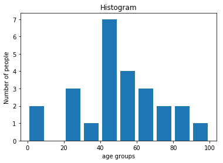

```python
population_age = [22,55,62,45,21,22,34,42,42,4,2,102,95,85,55,110,120,70,65,55,111,115,80,75,65,54,44,43,42,48]
bins = [0,10,20,30,40,50,60,70,80,90,100]
plt.hist(population_age, bins, histtype='bar', rwidth=0.8)
plt.xlabel('age groups')
plt.ylabel('Number of people')
plt.title('Histogram')
plt.show()
```

## Pie Charts:

Syntax: plt.pie([values_of_each_category],labels=[names_of_each_category],colors=,startangle=,shadow=True,explode=(separtion_between_the_slices),autopct=percentage_values_will_be_printed)

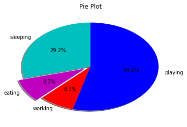

```python
days = [1,2,3,4,5]

sleeping =[7,8,6,11,7]
eating = [2,3,4,3,2]
working =[7,8,7,2,2]
playing = [8,5,7,8,13]
slices = [7,2,2,13]
activities = ['sleeping','eating','working','playing']
cols = ['c','m','r','b']

plt.pie(slices,
  labels=activities,
  colors=cols,
  startangle=90,
  shadow= True,
  explode=(0,0.1,0,0),
  autopct='%1.1f%%')

plt.title('Pie Plot')
plt.show()
```